# IODS course project

Sirja Viitamaki

# About the project

## Introduction to Open Data Science 2019

I am attending Introduction to Open Data Science (IODS) course fall 2019.

The course helps participants to understand possibilities of **open science, open data, and open research** tools. Here I will learn to use a few open software tools like [R](https://www.r-project.org/) and [GitHub](https://github.com/), and to visualize and analyze data sets with some fairly advanced statistical methods.

My supervisor recommended this course to me, and I believe it will be *very useful* for me.

### Links

- [My GitHub repository](https://github.com/sviitama/IODS-project-1)
- [My course diary](https://sviitama.github.io/IODS-project-1/)

### About me

I am a MSc in microbiology, I graduated last September. Now I have started my PhD project, where I will study the **functions and activity of microbial communities in Arctic and subarctic soils**. I work in Jenni Hultman’s research group, [Arctic Microbial Ecology](https://www.helsinki.fi/en/researchgroups/molecular-environmental-biosciences/research/arctic-microbial-ecology). Here you can find [my TUHAT page](https://researchportal.helsinki.fi/fi/persons/sirja-viitam%C3%A4ki).

# Week 2: Regression and model validation

## Preparations

```r
# Set working directory
setwd("C:/Users/sirja/Documents/IODS-project-1")
#setwd("Z:/Jatko-opinnot/IODS/IODS-project-1")

# Access needed libraries
library(ggplot2)
library(GGally)
```

## Task 1: Data exploration

```r
# Read the learning2014 data from folder "data"
learning2014 <- read.csv("data/learning2014.csv")

# Explore the data
str(learning2014)
```

```
## 'data.frame':    166 obs. of  7 variables:
##  $ gender  : Factor w/ 2 levels "F","M": 1 2 1 2 2 1 2 1 2 1 ...
##  $ age     : int  53 55 49 53 49 38 50 37 37 42 ...
##  $ attitude: int  37 31 25 35 37 38 35 29 38 21 ...
##  $ deep    : num  3.58 2.92 3.5 3.5 3.67 ...
##  $ stra    : num  3.38 2.75 3.62 3.12 3.62 ...
##  $ surf    : num  2.58 3.17 2.25 2.25 2.83 ...
##  $ points  : int  25 12 24 10 22 21 21 31 24 26 ...
```

```r
dim(learning2014)
```

```
## [1] 166   7
```

## Task 2: Visualize data

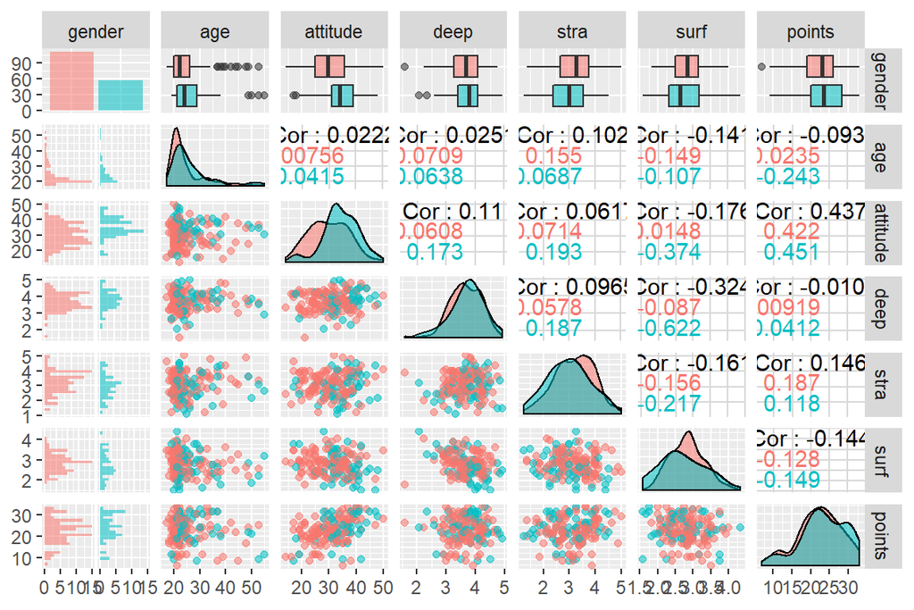

```r
# create a plot matrix with ggpairs()
p <- ggpairs(learning2014, mapping = aes(col = gender, alpha = 0.3), lower = list(combo = wrap("facethist", bins = 20)))

# draw the plot
p
```

> [Here](https://www.mv.helsinki.fi/home/kvehkala/JYTmooc/JYTOPKYS3-meta.txt) you can find more information on the data.

## Task 3: Regression model

```r
# create a regression model with three explanatory variables
reg_model <- lm(points ~ attitude + stra + age, data = learning2014)

# print out a summary of the model
summary(reg_model)
```

```
##
## Call:
## lm(formula = points ~ attitude + stra + age, data = learning2014)
##
## Residuals:
##      Min       1Q   Median       3Q      Max
## -18.1149  -3.2003   0.3303   3.4129  10.7599
##
## Coefficients:
##             Estimate Std. Error t value Pr(>|t|)
## (Intercept) 10.89543    2.64834   4.114 6.17e-05 ***
## attitude     0.34808    0.05622   6.191 4.72e-09 ***
## stra         1.00371    0.53434   1.878   0.0621 .
## age         -0.08822    0.05302  -1.664   0.0981 .
## ---
## Signif. codes:  0 '***' 0.001 '**' 0.01 '*' 0.05 '.' 0.1 ' ' 1
##
## Residual standard error: 5.26 on 162 degrees of freedom
## Multiple R-squared:  0.2182, Adjusted R-squared:  0.2037
## F-statistic: 15.07 on 3 and 162 DF,  p-value: 1.07e-08
```

```r
# Try with other variables
reg_model2 <- lm(points ~ stra + age + deep, data = learning2014)

# print out a summary of the model
summary(reg_model2)
```

```
##
## Call:
## lm(formula = points ~ stra + age + deep, data = learning2014)
##
## Residuals:
##      Min       1Q   Median       3Q      Max
## -16.9507  -3.7019   0.4378   4.0004  10.3058
##
## Coefficients:
##             Estimate Std. Error t value Pr(>|t|)
## (Intercept) 21.91769    3.65822   5.991  1.3e-08 ***
## stra         1.21807    0.59565   2.045   0.0425 *
## age         -0.08270    0.05894  -1.403   0.1625
## deep        -0.24262    0.82555  -0.294   0.7692
## ---
## Signif. codes:  0 '***' 0.001 '**' 0.01 '*' 0.05 '.' 0.1 ' ' 1
##
## Residual standard error: 5.848 on 162 degrees of freedom
## Multiple R-squared:  0.03369,    Adjusted R-squared:  0.01579
## F-statistic: 1.883 on 3 and 162 DF,  p-value: 0.1346
```

## Task 4: Interpretation

By trying different variable combinations in the model, it could be seen that attitude had significant relationship with the points, whenever it was included in the model. In addtion, strategic learning had a significant correlation with the points, when attitude was not included in the model. Age had some correlation with the points. but it was not significant.

## Task 5: Diagnostic plots

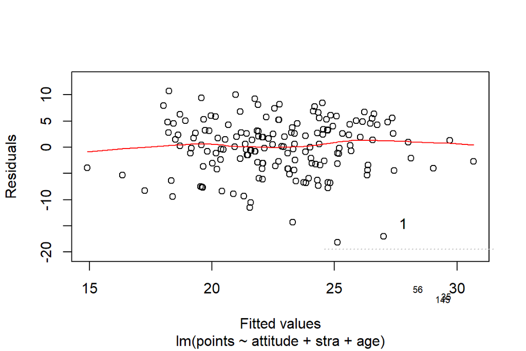

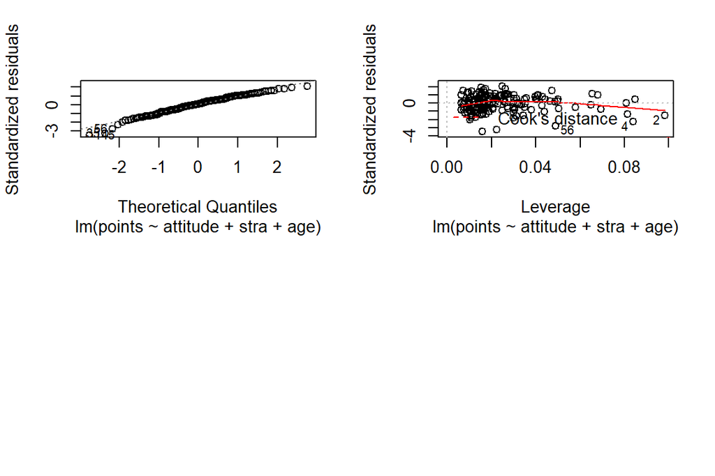

```r
# draw diagnostic plots : Residuals vs Fitted values, Normal QQ-plot and Residuals vs Leverage
plot(reg_model, which = c(1,2,5), par(mfrow = c(2,2)))
```

# Week 3: Logistic regression

## Preparations

```r
# Set working directory
setwd("C:/Users/sirja/Documents/IODS-project-1")
#setwd("Z:/Jatko-opinnot/IODS/IODS-project-1")

# Access needed libraries
library(tidyverse)
```

## Tasks 2 & 3: Data introduction and hypotheses

```r
# read the modified and joined dataset
alc <- read.csv("data/joined_data.csv")
# take a look of the data
glimpse(alc)
```

```
## Observations: 382
## Variables: 35
## $ school     <fct> GP, GP, GP, GP, GP, GP, GP, GP, GP, GP, GP, GP, GP,...
## $ sex        <fct> F, F, F, F, F, M, M, F, M, M, F, F, M, M, M, F, F, ...
## $ age        <int> 18, 17, 15, 15, 16, 16, 16, 17, 15, 15, 15, 15, 15,...
## $ address    <fct> U, U, U, U, U, U, U, U, U, U, U, U, U, U, U, U, U, ...
## $ famsize    <fct> GT3, GT3, LE3, GT3, GT3, LE3, LE3, GT3, LE3, GT3, G...
## $ Pstatus    <fct> A, T, T, T, T, T, T, A, A, T, T, T, T, T, A, T, T, ...
## $ Medu       <int> 4, 1, 1, 4, 3, 4, 2, 4, 3, 3, 4, 2, 4, 4, 2, 4, 4, ...
## $ Fedu       <int> 4, 1, 1, 2, 3, 3, 2, 4, 2, 4, 4, 1, 4, 3, 2, 4, 4, ...
## $ Mjob       <fct> at_home, at_home, at_home, health, other, services,...
## $ Fjob       <fct> teacher, other, other, services, other, other, othe...
## $ reason     <fct> course, course, other, home, home, reputation, home...
## $ nursery    <fct> yes, no, yes, yes, yes, yes, yes, yes, yes, yes, ye...
## $ internet   <fct> no, yes, yes, yes, no, yes, yes, no, yes, yes, yes,...
```

[output cut: 22 more lines]

Dataset “alc” contains data collected from secondary school students. Data includes information on the students’ background, grades, and alcohol consumption. Find more information on the data from [here](https://archive.ics.uci.edu/ml/datasets/Student+Performance).

Purpose of this analysis is to study the relationships between alcohol consumption and chosen variables in the data. I am interested in how the family, friends and romantic relationships affect the alcohol usage of the students, so I chose these four variables:

- famrel - quality of family relationships (numeric: from 1 - very bad to 5 - excellent)
- famsup - family educational support (binary: yes or no)
- romantic - with a romantic relationship (binary: yes or no)
- goout - going out with friends (numeric: from 1 - very low to 5 - very high)

I hypothesize that the chosen variables and alcohol consumption have following relationships:

- H1 Good family relations are connected to low alcohol usage
- H2 Family educational support is connected to low alcohol usage
- H3 Romantic relationship does not have a clear connection with alcohol usage
- H4 Going out with friends is connected to high alcohol usage

## Task 4: Data exploration

```r
var <- c("goout", "famsup", "romantic", "famrel", "alc_use", "high_use")
alc_family <- subset(alc, select = var)

gather(alc_family) %>% glimpse()
```

```
## Observations: 2,292
## Variables: 2
## $ key   <chr> "goout", "goout", "goout", "goout", "goout", "goout", "g...
## $ value <chr> "4", "3", "2", "2", "2", "2", "4", "4", "2", "1", "3", "...
```

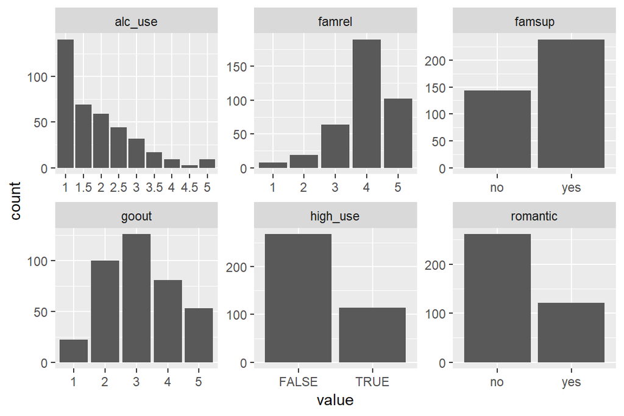

```r
gather(alc_family) %>% ggplot(aes(value)) + facet_wrap("key", scales = "free") + geom_bar()
```

Barplot shows that observations of alcohol usage is skewed so that there are much more observations of low alcohol consuption, thus there are also more false observations of high alcohol use. Variable “goout” is normally distributed, whereas famrel is slightly skewed to higher values, meaning that most students have good family relations in this dataset. Additionally, most students are not in a romantic relationship and most get educational support from their families.

```r
# produce summary statistics by group
alc_family %>% group_by(famsup, high_use) %>% summarise(count = n(), mean_goout = mean(goout), mean_famrel = mean(famrel), mean_alcuse = mean(alc_use))
```

```
## # A tibble: 4 x 6
## # Groups:   famsup [2]
##   famsup high_use count mean_goout mean_famrel mean_alcuse
##   <fct>  <lgl>    <int>      <dbl>       <dbl>       <dbl>
## 1 no     FALSE       98       2.81        4           1.38
## 2 no     TRUE        46       3.85        3.83        3.21
## 3 yes    FALSE      170       2.88        4.01        1.33
## 4 yes    TRUE        68       3.63        3.75        3.12
```

By looking this table, it seems that students who go out often use more alcohol than the ones who don’t go out. Also, having good family relationships and getting family support for studying might be connected to lower usage of alcohol.

```r
# produce summary statistics by group
alc_family %>% group_by(romantic, high_use) %>% summarise(count = n(), mean_goout = mean(goout), mean_famrel = mean(famrel), mean_alcuse = mean(alc_use))
```

```
## # A tibble: 4 x 6
## # Groups:   romantic [2]
##   romantic high_use count mean_goout mean_famrel mean_alcuse
##   <fct>    <lgl>    <int>      <dbl>       <dbl>       <dbl>
## 1 no       FALSE      180       2.82        4.08        1.32
## 2 no       TRUE        81       3.73        3.74        3.07
## 3 yes      FALSE       88       2.92        3.84        1.40
## 4 yes      TRUE        33       3.70        3.88        3.36
```

Interestingly, it also looks like the ones who are not in a romantic relationship, might use more alcohol if their family relationship is poor.

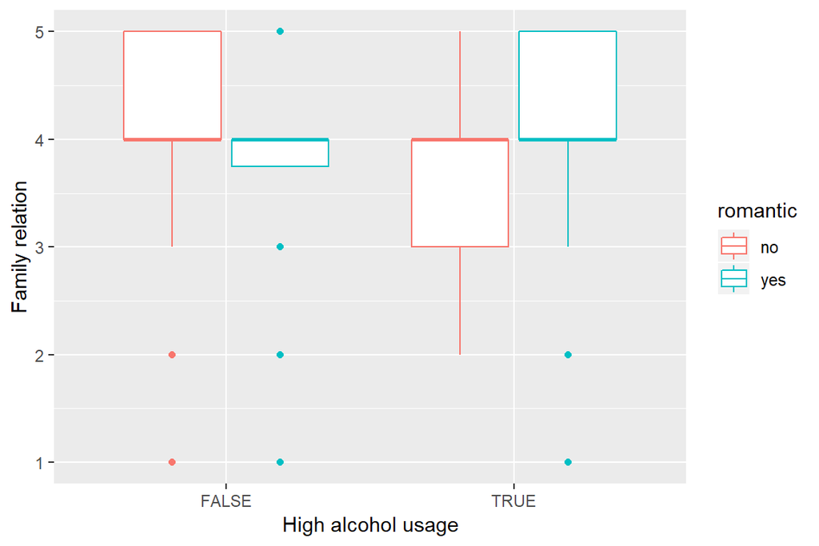

```r
g1 <- ggplot(alc_family, aes(x = high_use, y = famrel, col = romantic))

# define the plot as a boxplot and draw it
g1 + geom_boxplot() + ylab("Family relation") + xlab("High alcohol usage")
```

This boxplot shows indeed that the students not in a relationship are more often high alcohol consumers, when their family relationship is not good.

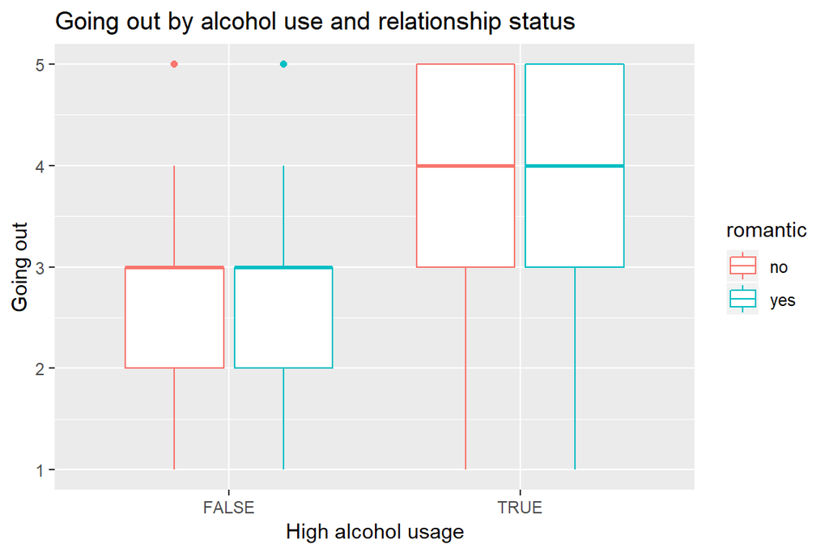

```r
# initialise a plot of high_use and going out
g2 <- ggplot(alc_family, aes(x = high_use, y = goout, col = romantic))

# define the plot as a boxplot and draw it
g2 + geom_boxplot() + ylab("Going out") + xlab("High alcohol usage") + ggtitle("Going out by alcohol use and relationship status")
```

Going out with friends seemed to be connected positively with high alcohol usage, whether the student was is a relationship or not.

## Task 5: Logistic regression

```r
# find the model with glm()
m <- glm(high_use ~ goout + famsup + famrel + romantic, data = alc, family = "binomial")

# print out a summary of the model
summary(m)
```

```
##
## Call:
## glm(formula = high_use ~ goout + famsup + famrel + romantic,
##     family = "binomial", data = alc)
##
## Deviance Residuals:
##     Min       1Q   Median       3Q      Max
## -1.6331  -0.7741  -0.5625   0.9753   2.4552
##
## Coefficients:
##             Estimate Std. Error z value Pr(>|z|)
## (Intercept)  -1.8194     0.6408  -2.839  0.00452 **
## goout         0.7956     0.1186   6.711 1.94e-11 ***
## famsupyes    -0.1546     0.2493  -0.620  0.53506
## famrel       -0.3770     0.1338  -2.818  0.00483 **
## romanticyes  -0.2774     0.2657  -1.044  0.29650
## ---
## Signif. codes:  0 '***' 0.001 '**' 0.01 '*' 0.05 '.' 0.1 ' ' 1
##
## (Dispersion parameter for binomial family taken to be 1)
##
##     Null deviance: 465.68  on 381  degrees of freedom
## Residual deviance: 406.60  on 377  degrees of freedom
## AIC: 416.6
##
## Number of Fisher Scoring iterations: 4
```

```r
# print out the coefficients of the model
coef(m)
```

```
## (Intercept)       goout   famsupyes      famrel romanticyes
##  -1.8194377   0.7956040  -0.1546234  -0.3769937  -0.2773591
```

Based on the model, going out with friends is positively correlated (estimate of coefficient = 0.7956) with higher alcohol usage, and it is also statistically significant (p<0.001) Model also shows that good family relations correlate negatively (estimate of coefficient = -0.3770) with high alcohol usage with significance of p<0.01. Having family support on studies and romantic relationship both correlated negatively but unsignificantly with high alcohol consumption.

**Conclusions:** Students who often go out with their friends are more likely to consume higher amounts of alcohol than the ones who don’t go out so often. Also, students with good family relations are less likely high alcohol consumers compared to those who have worse relationship with their families. Thus, hypotheses H1, H3, and H4 were confirmed.

```r
# compute odds ratios (OR) and confidence intervals (CI)
OR <- coef(m) %>% exp
CI <- confint(m) %>% exp

# print out the odds ratios with their confidence intervals
cbind(OR, CI)
```

```
##                    OR      2.5 %    97.5 %
## (Intercept) 0.1621169 0.04464896 0.5551432
## goout       2.2157789 1.76741953 2.8159145
## famsupyes   0.8567378 0.52605327 1.4004738
## famrel      0.6859204 0.52630839 0.8907860
## romanticyes 0.7577823 0.44609399 1.2672687
```

## Task 6: Binary predictions

```r
# fit the model
m <- glm(high_use ~ famrel+ goout, data = alc, family = "binomial")
# predict() the probability of high_use
probabilities <- predict(m, type = "response")
# add the predicted probabilities to 'alc'
alc <- mutate(alc, probability = probabilities)
# use the probabilities to make a prediction of high_use
alc <- mutate(alc, prediction = probability > 0.5)
# tabulate the target variable versus the predictions
table(high_use = alc$high_use, prediction = alc$prediction)
```

```
##         prediction
## high_use FALSE TRUE
##    FALSE   243   25
##    TRUE     68   46
```

Based on the table above, training error can be calculated: (68+25)/382 = 0,243455… = 24 %. This means that the **model correctly predicted the alcohol usage of the students in 76 % of the cases**.

# Week 4. Clustering and classification

## Preparations

```r
# Set working directory
#setwd("Z:/Jatko-opinnot/IODS/IODS-project-1")
setwd("C:/Users/sirja/Documents/IODS-project-1")

# Access needed libraries
library("MASS")
library("tidyverse")
library("corrplot")
```

## Task 2: Data exploration

```r
# load the data
data("Boston")

# explore the dataset
str(Boston)
```

```
## 'data.frame':    506 obs. of  14 variables:
##  $ crim   : num  0.00632 0.02731 0.02729 0.03237 0.06905 ...
##  $ zn     : num  18 0 0 0 0 0 12.5 12.5 12.5 12.5 ...
##  $ indus  : num  2.31 7.07 7.07 2.18 2.18 2.18 7.87 7.87 7.87 7.87 ...
##  $ chas   : int  0 0 0 0 0 0 0 0 0 0 ...
##  $ nox    : num  0.538 0.469 0.469 0.458 0.458 0.458 0.524 0.524 0.524 0.524 ...
##  $ rm     : num  6.58 6.42 7.18 7 7.15 ...
##  $ age    : num  65.2 78.9 61.1 45.8 54.2 58.7 66.6 96.1 100 85.9 ...
##  $ dis    : num  4.09 4.97 4.97 6.06 6.06 ...
##  $ rad    : int  1 2 2 3 3 3 5 5 5 5 ...
##  $ tax    : num  296 242 242 222 222 222 311 311 311 311 ...
##  $ ptratio: num  15.3 17.8 17.8 18.7 18.7 18.7 15.2 15.2 15.2 15.2 ...
##  $ black  : num  397 397 393 395 397 ...
##  $ lstat  : num  4.98 9.14 4.03 2.94 5.33 ...
##  $ medv   : num  24 21.6 34.7 33.4 36.2 28.7 22.9 27.1 16.5 18.9 ...
```

Dataset “Boston” contains housing values in suburbs of Boston. It is a matrix with 506 rows and 14 columns. Rows are towns in Boston and columns are variables such as crime rate or pupil-teacher ratio by town. More information on the data can be found [here](https://stat.ethz.ch/R-manual/R-devel/library/MASS/html/Boston.html).

## Task 3: Correlation matrix

```r
# calculate the correlation matrix and round it
cor_matrix<-cor(Boston)

# print the correlation matrix
cor_matrix %>% round(digits = 2)
```

```
##          crim    zn indus  chas   nox    rm   age   dis   rad   tax
## crim     1.00 -0.20  0.41 -0.06  0.42 -0.22  0.35 -0.38  0.63  0.58
## zn      -0.20  1.00 -0.53 -0.04 -0.52  0.31 -0.57  0.66 -0.31 -0.31
## indus    0.41 -0.53  1.00  0.06  0.76 -0.39  0.64 -0.71  0.60  0.72
## chas    -0.06 -0.04  0.06  1.00  0.09  0.09  0.09 -0.10 -0.01 -0.04
## nox      0.42 -0.52  0.76  0.09  1.00 -0.30  0.73 -0.77  0.61  0.67
## rm      -0.22  0.31 -0.39  0.09 -0.30  1.00 -0.24  0.21 -0.21 -0.29
## age      0.35 -0.57  0.64  0.09  0.73 -0.24  1.00 -0.75  0.46  0.51
## dis     -0.38  0.66 -0.71 -0.10 -0.77  0.21 -0.75  1.00 -0.49 -0.53
## rad      0.63 -0.31  0.60 -0.01  0.61 -0.21  0.46 -0.49  1.00  0.91
## tax      0.58 -0.31  0.72 -0.04  0.67 -0.29  0.51 -0.53  0.91  1.00
## ptratio  0.29 -0.39  0.38 -0.12  0.19 -0.36  0.26 -0.23  0.46  0.46
## black   -0.39  0.18 -0.36  0.05 -0.38  0.13 -0.27  0.29 -0.44 -0.44
## lstat    0.46 -0.41  0.60 -0.05  0.59 -0.61  0.60 -0.50  0.49  0.54
## medv    -0.39  0.36 -0.48  0.18 -0.43  0.70 -0.38  0.25 -0.38 -0.47
##         ptratio black lstat  medv
## crim       0.29 -0.39  0.46 -0.39
## zn        -0.39  0.18 -0.41  0.36
## indus      0.38 -0.36  0.60 -0.48
## chas      -0.12  0.05 -0.05  0.18
## nox        0.19 -0.38  0.59 -0.43
## rm        -0.36  0.13 -0.61  0.70
## age        0.26 -0.27  0.60 -0.38
## dis       -0.23  0.29 -0.50  0.25
## rad        0.46 -0.44  0.49 -0.38
## tax        0.46 -0.44  0.54 -0.47
## ptratio    1.00 -0.18  0.37 -0.51
## black     -0.18  1.00 -0.37  0.33
## lstat      0.37 -0.37  1.00 -0.74
## medv      -0.51  0.33 -0.74  1.00
```

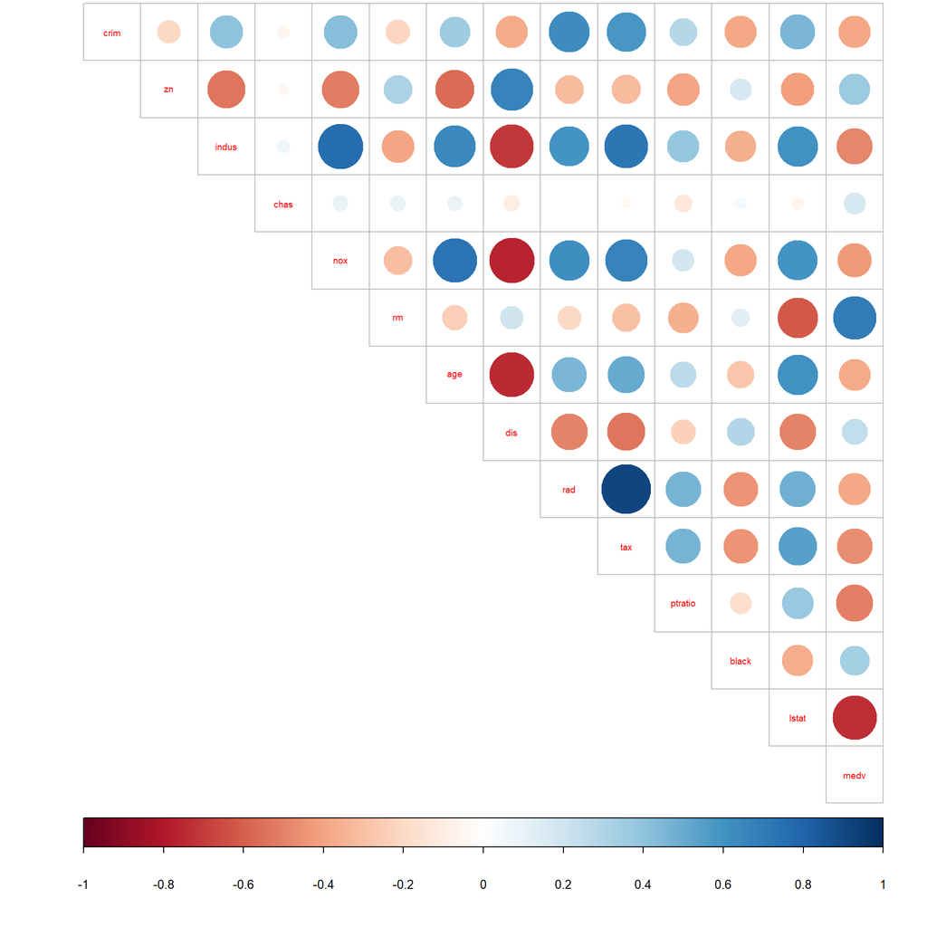

```r
# visualize the correlation matrix
corrplot(cor_matrix, method="circle", type = "upper", cl.pos = "b", tl.pos = "d", tl.cex = 0.6)
```

This correlation plot shows the correlation between the variables.

> “[The corrplot package](https://cran.r-project.org/web/packages/corrplot/vignettes/corrplot-intro.html) is a graphical display of a correlation matrix, confidence interval. It also contains some algorithms to do matrix reordering. In addition, corrplot is good at details, including choosing color, text labels, color labels, layout, etc. Positive correlations are displayed in blue and negative correlations in red color. Color intensity and the size of the circle are proportional to the correlation coefficients.”

## Task 4: Data wrangling, test & train sets

Standardize the dataset.

```r
# center and standardize variables
boston_scaled <- scale(Boston)

# summaries of the scaled variables
summary(boston_scaled)
```

```
##       crim                 zn               indus
##  Min.   :-0.419367   Min.   :-0.48724   Min.   :-1.5563
##  1st Qu.:-0.410563   1st Qu.:-0.48724   1st Qu.:-0.8668
##  Median :-0.390280   Median :-0.48724   Median :-0.2109
##  Mean   : 0.000000   Mean   : 0.00000   Mean   : 0.0000
##  3rd Qu.: 0.007389   3rd Qu.: 0.04872   3rd Qu.: 1.0150
##  Max.   : 9.924110   Max.   : 3.80047   Max.   : 2.4202
##       chas              nox                rm               age
##  Min.   :-0.2723   Min.   :-1.4644   Min.   :-3.8764   Min.   :-2.3331
##  1st Qu.:-0.2723   1st Qu.:-0.9121   1st Qu.:-0.5681   1st Qu.:-0.8366
##  Median :-0.2723   Median :-0.1441   Median :-0.1084   Median : 0.3171
##  Mean   : 0.0000   Mean   : 0.0000   Mean   : 0.0000   Mean   : 0.0000
##  3rd Qu.:-0.2723   3rd Qu.: 0.5981   3rd Qu.: 0.4823   3rd Qu.: 0.9059
##  Max.   : 3.6648   Max.   : 2.7296   Max.   : 3.5515   Max.   : 1.1164
##       dis               rad               tax             ptratio
##  Min.   :-1.2658   Min.   :-0.9819   Min.   :-1.3127   Min.   :-2.7047
##  1st Qu.:-0.8049   1st Qu.:-0.6373   1st Qu.:-0.7668   1st Qu.:-0.4876
##  Median :-0.2790   Median :-0.5225   Median :-0.4642   Median : 0.2746
##  Mean   : 0.0000   Mean   : 0.0000   Mean   : 0.0000   Mean   : 0.0000
##  3rd Qu.: 0.6617   3rd Qu.: 1.6596   3rd Qu.: 1.5294   3rd Qu.: 0.8058
##  Max.   : 3.9566   Max.   : 1.6596   Max.   : 1.7964   Max.   : 1.6372
##      black             lstat              medv
##  Min.   :-3.9033   Min.   :-1.5296   Min.   :-1.9063
##  1st Qu.: 0.2049   1st Qu.:-0.7986   1st Qu.:-0.5989
##  Median : 0.3808   Median :-0.1811   Median :-0.1449
##  Mean   : 0.0000   Mean   : 0.0000   Mean   : 0.0000
##  3rd Qu.: 0.4332   3rd Qu.: 0.6024   3rd Qu.: 0.2683
##  Max.   : 0.4406   Max.   : 3.5453   Max.   : 2.9865
```

```r
# check the class of the boston_scaled object
class(boston_scaled)
```

```
## [1] "matrix"
```

```r
# change the object to data frame
boston_scaled <- as.data.frame(boston_scaled)
# summary of the scaled crime rate
summary(boston_scaled$crim)
```

```
##      Min.   1st Qu.    Median      Mean   3rd Qu.      Max.
## -0.419367 -0.410563 -0.390280  0.000000  0.007389  9.924110
```

Variables change so that their mean is always zero, and maximum and minimum values are more in a similar scale, approximately from -5 to 10.

Create a categorical variable of the crime rate with quantiles as the break points.

```r
# create a quantile vector of crim and print it
bins <- quantile(boston_scaled$crim)
bins
```

```
##           0%          25%          50%          75%         100%
## -0.419366929 -0.410563278 -0.390280295  0.007389247  9.924109610
```

```r
# create a categorical variable 'crime'
crime <- cut(boston_scaled$crim, breaks = bins, include.lowest = TRUE, label = c("low", "med_low", "med_high", "high"))

# look at the table of the new factor crime
crime
```

```
##   [1] low      low      low      low      low      low      med_low
##   [8] med_low  med_low  med_low  med_low  med_low  med_low  med_high
##  [15] med_high med_high med_high med_high med_high med_high med_high
##  [22] med_high med_high med_high med_high med_high med_high med_high
##  [29] med_high med_high med_high med_high med_high med_high med_high
##  [36] low      med_low  low      med_low  low      low      med_low
##  [43] med_low  med_low  med_low  med_low  med_low  med_low  med_low
##  [50] med_low  med_low  low      low      low      low      low
##  [57] low      low      med_low  med_low  med_low  med_low  med_low
##  [64] med_low  low      low      low      low      med_low  med_low
##  [71] med_low  med_low  med_low  med_low  low      med_low  med_low
##  [78] med_low  low      med_low  low      low      low      low
##  [85] low      low      low      low      low      low      low
##  [92] low      low      low      low      med_low  med_low  med_low
##  [99] low      low      med_low  med_low  med_low  med_low  med_low
```

[output cut: 59 more lines]

```r
# remove original crim from the dataset
boston_scaled <- dplyr::select(boston_scaled, -crim)

# add the new categorical value to scaled data
boston_scaled <- data.frame(boston_scaled, crime)
```

Divide the dataset to train and test sets, so that 80% of the data belongs to the train set.

```r
# number of rows in the Boston dataset
n <- nrow(boston_scaled)

# choose randomly 80% of the rows
ind <- sample(n,  size = n * 0.8)

# create train set
train <- boston_scaled[ind,]

# create test set
test <- boston_scaled[-ind,]

# save the correct classes from test data
correct_classes <- test$crime

# remove the crime variable from test data
test <- dplyr::select(test, -crime)
```

## Task 5: Linear discriminant analysis

Fit the linear discriminant analysis on the train set with categorical crime rate as the target variable.

```r
# linear discriminant analysis
lda.fit <- lda(crime ~ ., data = train)

# print the lda.fit object
lda.fit
```

```
## Call:
## lda(crime ~ ., data = train)
##
## Prior probabilities of groups:
##       low   med_low  med_high      high
## 0.2475248 0.2747525 0.2227723 0.2549505
##
## Group means:
##                  zn      indus        chas        nox         rm
## low       0.9845175 -0.9525281 -0.11484506 -0.9032547  0.4473213
## med_low  -0.1276130 -0.2751578 -0.02404347 -0.5626585 -0.1752446
## med_high -0.3805238  0.1852673  0.20887207  0.3369880  0.1235682
## high     -0.4872402  1.0149946 -0.04298342  1.0449091 -0.4925875
##                 age        dis        rad        tax     ptratio
## low      -0.9158062  0.9598464 -0.6970514 -0.7213079 -0.47369949
## med_low  -0.3123721  0.3349471 -0.5504201 -0.4733539 -0.04312877
## med_high  0.4356833 -0.3542840 -0.4178463 -0.3140979 -0.23453515
## high      0.8284269 -0.8760354  1.6596029  1.5294129  0.80577843
##               black       lstat        medv
## low       0.3805556 -0.78731478  0.53638554
## med_low   0.3124301 -0.10278082 -0.03569622
## med_high  0.1056171  0.05027934  0.16822618
## high     -0.7730680  0.88886256 -0.65594629
##
## Coefficients of linear discriminants:
##                 LD1         LD2          LD3
## zn       0.08166817  0.67491385 -0.867017678
## indus    0.11256503 -0.36795972  0.282307638
## chas    -0.07865580 -0.09095997  0.088188332
## nox      0.19854548 -0.77058550 -1.489019287
## rm      -0.13843989 -0.15342609 -0.248081016
## age      0.23644006 -0.30921746 -0.135295206
## dis     -0.05208951 -0.27221224  0.009766894
## rad      3.73893587  1.01166243  0.046051627
## tax     -0.01543678  0.04704681  0.479056014
## ptratio  0.08575859 -0.03605832 -0.220457061
## black   -0.14483260  0.01698313  0.104559478
## lstat    0.20193629 -0.30232628  0.244166960
## medv     0.20601852 -0.36478116 -0.225129668
##
## Proportion of trace:
##    LD1    LD2    LD3
## 0.9577 0.0316 0.0107
```

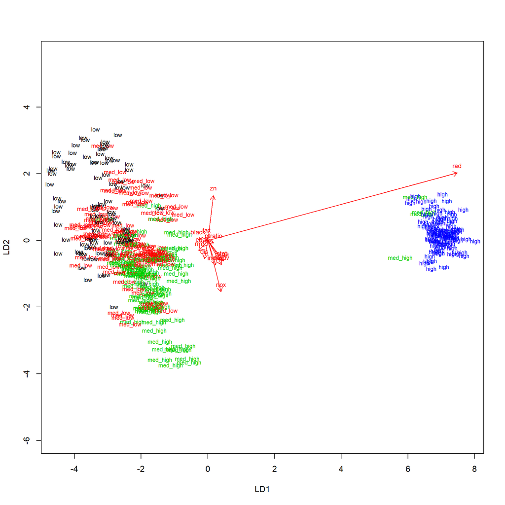

```r
# the function for lda biplot arrows
lda.arrows <- function(x, myscale = 1, arrow_heads = 0.1, color = "red", tex = 0.75, choices = c(1,2)){
  heads <- coef(x)
  arrows(x0 = 0, y0 = 0,
         x1 = myscale * heads[,choices[1]],
         y1 = myscale * heads[,choices[2]], col=color, length = arrow_heads)
  text(myscale * heads[,choices], labels = row.names(heads),
       cex = tex, col=color, pos=3)
}

# target classes as numeric
classes <- as.numeric(train$crime)

# plot the lda results
plot(lda.fit, dimen = 2, col = classes, pch = classes)
lda.arrows(lda.fit, myscale = 2)
```

## Task 6: Prediction

```r
# predict classes with test data
lda.pred <- predict(lda.fit, newdata = test)

# cross tabulate the results
table(correct = correct_classes, predicted = lda.pred$class)
```

```
##           predicted
## correct    low med_low med_high high
##   low       15      10        2    0
##   med_low    4       9        2    0
##   med_high   0      11       23    2
##   high       0       0        1   23
```

## Task 7: K-means

```r
data(Boston)

# standardize the dataset
boston_scaled <- scale(Boston)
boston_scaled <- as.data.frame(boston_scaled)
```

Calculate Euclidean distances between the observations

```r
# euclidean distance matrix
dist_eu <- dist(boston_scaled)

# look at the summary of the distances
summary(dist_eu)
```

```
##    Min. 1st Qu.  Median    Mean 3rd Qu.    Max.
##  0.1343  3.4625  4.8241  4.9111  6.1863 14.3970
```

Run k-means algorithm

```r
# k-means clustering
km <-kmeans(boston_scaled, centers = 3)
```

Investigate what is the optimal number of clusters and run the algorithm again.

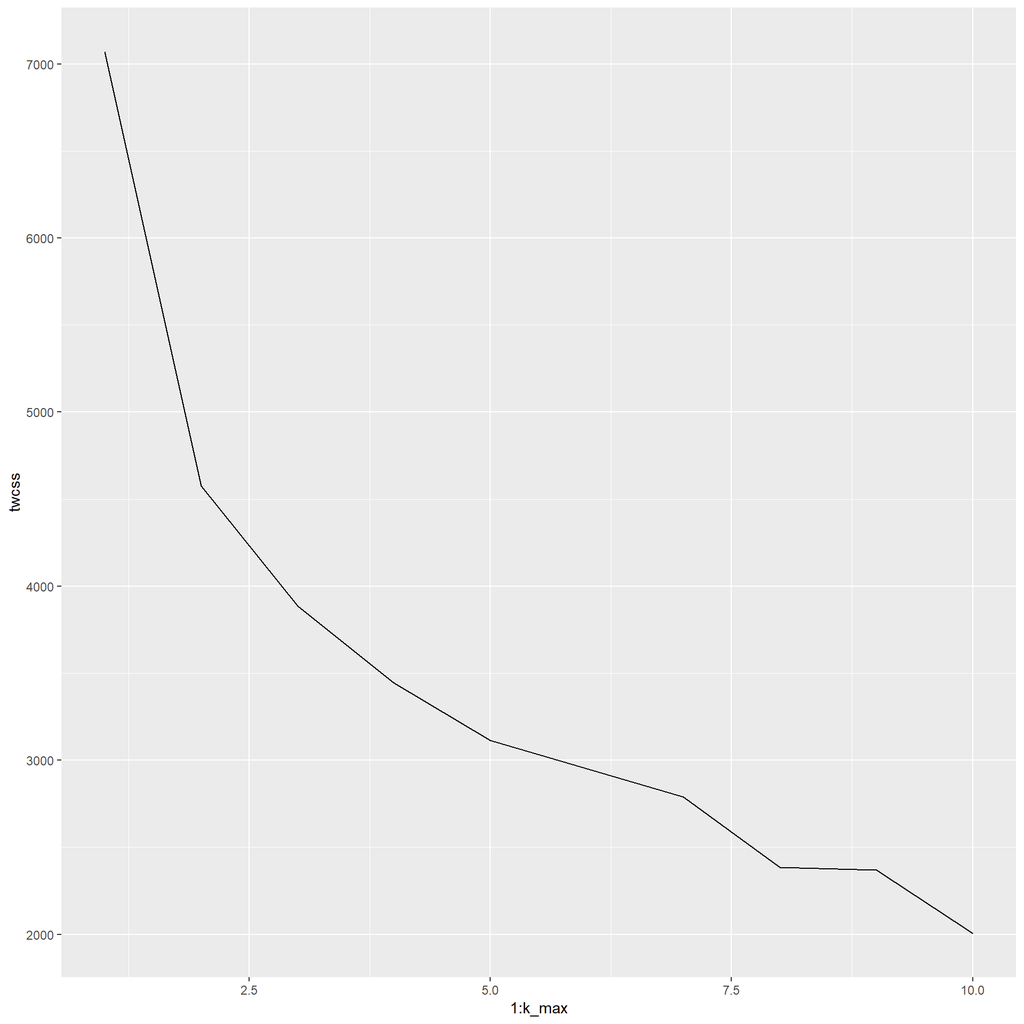

```r
set.seed(123)

# determine the number of clusters
k_max <- 10

# calculate the total within sum of squares
twcss <- sapply(1:k_max, function(k){kmeans(boston_scaled, k)$tot.withinss})

# visualize the results
qplot(x = 1:k_max, y = twcss, geom = 'line')
```

Based on the curve two is a good number of clusters.

```r
# k-means clustering
km <-kmeans(boston_scaled, centers = 2)
```

Visualize the clusters

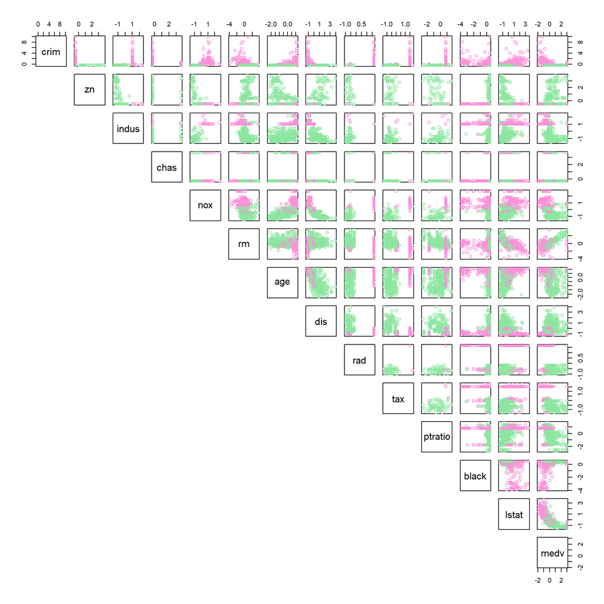

```r
# plot the Boston dataset with clusters
pairs(boston_scaled, col = c("#fc90d9", "#8de6a0")[km$cluster], lower.panel = NULL)
```

# Week 5. Dimensionality reduction techniques

## Preparations

```r
# Set working directory
#setwd("Z:/Jatko-opinnot/IODS/IODS-project-1")
setwd("C:/Users/sirja/Documents/IODS-project-1")

# Access needed libraries
library("tidyverse")
library("GGally")
library("FactoMineR")
```

```r
# load the data
human <- read.csv("data/human.csv", row.names = 1)

# explore the dataset
str(human)
```

```
## 'data.frame':    155 obs. of  8 variables:
##  $ EduRatio   : num  1.007 0.997 0.983 0.989 0.969 ...
##  $ LabourRatio: num  0.891 0.819 0.825 0.884 0.829 ...
##  $ ExpEdu     : num  17.5 20.2 15.8 18.7 17.9 16.5 18.6 16.5 15.9 19.2 ...
##  $ LifeExp    : num  81.6 82.4 83 80.2 81.6 80.9 80.9 79.1 82 81.8 ...
##  $ GNI        : int  64992 42261 56431 44025 45435 43919 39568 52947 42155 32689 ...
##  $ MatMort    : int  4 6 6 5 6 7 9 28 11 8 ...
##  $ AdolBirth  : num  7.8 12.1 1.9 5.1 6.2 3.8 8.2 31 14.5 25.3 ...
##  $ ParlRep    : num  39.6 30.5 28.5 38 36.9 36.9 19.9 19.4 28.2 31.4 ...
```

## Task 1: Overview of the data

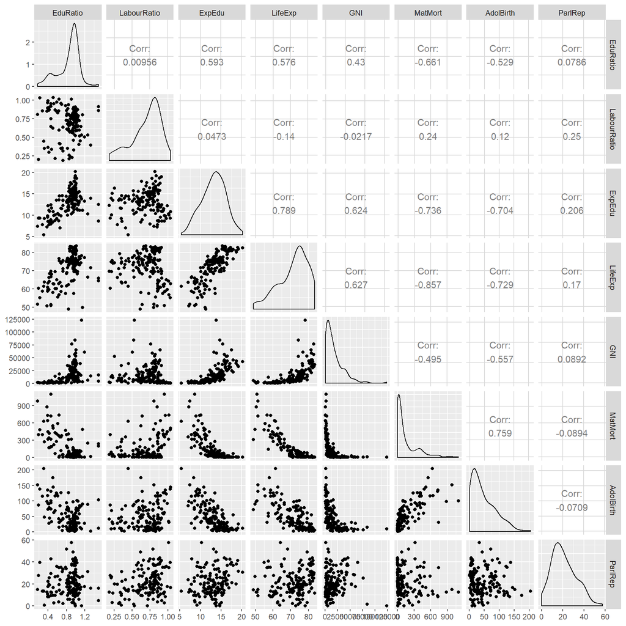

```r
ggpairs(human)
```

```r
summary(human)
```

```
##     EduRatio       LabourRatio         ExpEdu         LifeExp
##  Min.   :0.1717   Min.   :0.1857   Min.   : 5.40   Min.   :49.00
##  1st Qu.:0.7264   1st Qu.:0.5984   1st Qu.:11.25   1st Qu.:66.30
##  Median :0.9375   Median :0.7535   Median :13.50   Median :74.20
##  Mean   :0.8529   Mean   :0.7074   Mean   :13.18   Mean   :71.65
##  3rd Qu.:0.9968   3rd Qu.:0.8535   3rd Qu.:15.20   3rd Qu.:77.25
##  Max.   :1.4967   Max.   :1.0380   Max.   :20.20   Max.   :83.50
##       GNI            MatMort         AdolBirth         ParlRep
##  Min.   :   581   Min.   :   1.0   Min.   :  0.60   Min.   : 0.00
##  1st Qu.:  4198   1st Qu.:  11.5   1st Qu.: 12.65   1st Qu.:12.40
##  Median : 12040   Median :  49.0   Median : 33.60   Median :19.30
##  Mean   : 17628   Mean   : 149.1   Mean   : 47.16   Mean   :20.91
##  3rd Qu.: 24512   3rd Qu.: 190.0   3rd Qu.: 71.95   3rd Qu.:27.95
##  Max.   :123124   Max.   :1100.0   Max.   :204.80   Max.   :57.50
```

Most variables seem to be quite normally distributed. GNI, maternal mortality and adolescent birth rate are skewed. Many variables correlate. For example expected education and life expectancy have strong positive correlation, wheras maternal mortality life expectancy have strong negative correlation.

## Task 2: Principal component analysis

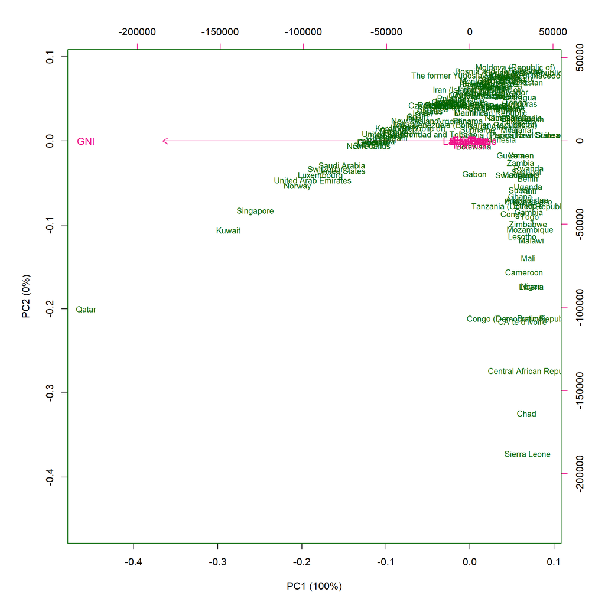

```r
# perform PCA
pca_human <- prcomp(human)
s <-summary(pca_human)
pca_pr <- round(100*s$importance[2, ], digits = 1)
pc_lab <- paste0(names(pca_pr), " (", pca_pr, "%)")

# draw a biplot
biplot(pca_human, cex = c(0.8, 1), col = c("darkgreen", "deeppink2"), xlab = pc_lab[1], ylab = pc_lab[2])
```

The figure looks strange because GNI has so much bigger variance than other variables. That’s why GNI explains 100% of variation here. Standardizing the data can solve the problem.

## Tasks 3 & 4: PCA with standardized data

```r
human_scaled <- scale(human)
pca_human <- prcomp(human_scaled)
s <- summary(pca_human)
pca_pr <- round(100*s$importance[2, ], digits = 1)
pca_pr
```

```
##  PC1  PC2  PC3  PC4  PC5  PC6  PC7  PC8
## 53.6 16.2  9.6  7.6  5.5  3.6  2.6  1.3
```

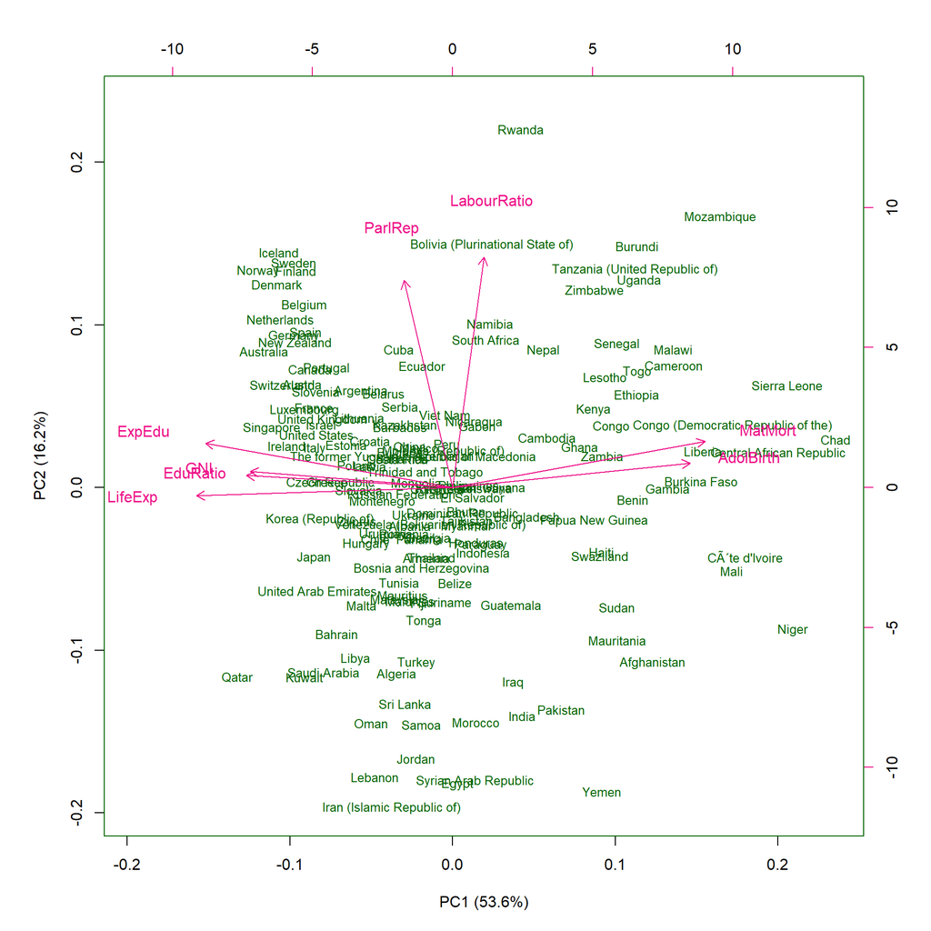

```r
pc_lab <- paste0(names(pca_pr), " (", pca_pr, "%)")
biplot(pca_human, cex = c(0.8, 1), col = c("darkgreen", "deeppink2"), xlab = pc_lab[1], ylab = pc_lab[2])
```

## Task 5: Multiple Correspondence Analysis

```r
# acquire the tea dataset
data(tea)

# explore the data
str(tea)
```

```
## 'data.frame':    300 obs. of  36 variables:
##  $ breakfast       : Factor w/ 2 levels "breakfast","Not.breakfast": 1 1 2 2 1 2 1 2 1 1 ...
##  $ tea.time        : Factor w/ 2 levels "Not.tea time",..: 1 1 2 1 1 1 2 2 2 1 ...
##  $ evening         : Factor w/ 2 levels "evening","Not.evening": 2 2 1 2 1 2 2 1 2 1 ...
##  $ lunch           : Factor w/ 2 levels "lunch","Not.lunch": 2 2 2 2 2 2 2 2 2 2 ...
##  $ dinner          : Factor w/ 2 levels "dinner","Not.dinner": 2 2 1 1 2 1 2 2 2 2 ...
##  $ always          : Factor w/ 2 levels "always","Not.always": 2 2 2 2 1 2 2 2 2 2 ...
##  $ home            : Factor w/ 2 levels "home","Not.home": 1 1 1 1 1 1 1 1 1 1 ...
##  $ work            : Factor w/ 2 levels "Not.work","work": 1 1 2 1 1 1 1 1 1 1 ...
##  $ tearoom         : Factor w/ 2 levels "Not.tearoom",..: 1 1 1 1 1 1 1 1 1 2 ...
##  $ friends         : Factor w/ 2 levels "friends","Not.friends": 2 2 1 2 2 2 1 2 2 2 ...
##  $ resto           : Factor w/ 2 levels "Not.resto","resto": 1 1 2 1 1 1 1 1 1 1 ...
##  $ pub             : Factor w/ 2 levels "Not.pub","pub": 1 1 1 1 1 1 1 1 1 1 ...
##  $ Tea             : Factor w/ 3 levels "black","Earl Grey",..: 1 1 2 2 2 2 2 1 2 1 ...
##  $ How             : Factor w/ 4 levels "alone","lemon",..: 1 3 1 1 1 1 1 3 3 1 ...
```

[output cut: 22 more lines]

```r
dim(tea)
```

```
## [1] 300  36
```

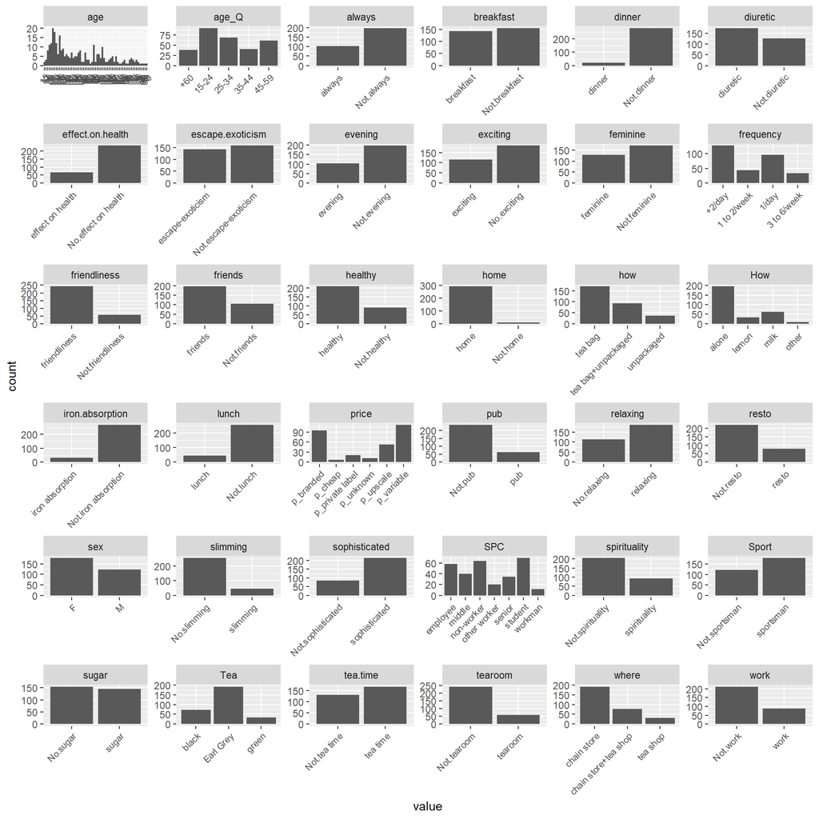

```r
# visualize
gather(tea) %>% ggplot(aes(value)) + geom_bar() + facet_wrap("key", scales = "free") + theme(axis.text.x = element_text(angle = 45, hjust = 1, size = 8))
```

Let’s select few variables for MCA

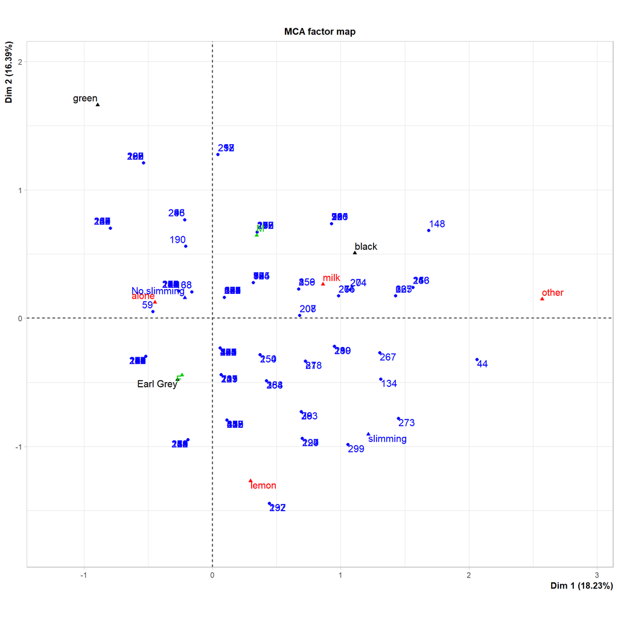

```r
# select variables
keep_columns <- c("Tea", "How", "sex", "slimming")
tea_time <- dplyr::select(tea, one_of(keep_columns))

# do MCA
mca <- MCA(tea_time, graph = FALSE)
plot(mca, invisible= "none" , habillage = "quali")
```

Based on the MCA, people who drink black tea are often men and add more often milk or other accompaniment to their tea than they who drink Earl Grey or green tea. Earl grey drinkers, who are more often women than men, add lemon more often than other. People who drink green tea don’t do it for slimming effect. Tea drinkers looking for slimming effect add lemon or other accompaniment, but no milk to their tea.

# Week 6. Analysis of longitudinal data

## Preparations

```r
# Set working directory
#setwd("Z:/Jatko-opinnot/IODS/IODS-project-1")
setwd("C:/Users/sirja/Documents/IODS-project-1")

# Access needed libraries
library("tidyverse")
library("lme4")
library("gridExtra")
```

```r
# load the data
BPRSL <- read.csv("data/BPRSL.txt", row.names = 1)
RATSL <- read.csv("data/RATSL.txt", row.names = 1)

# explore the dataset
str(BPRSL)
```

```
## 'data.frame':    360 obs. of  5 variables:
##  $ treatment: int  1 1 1 1 1 1 1 1 1 1 ...
##  $ subject  : int  1 2 3 4 5 6 7 8 9 10 ...
##  $ weeks    : Factor w/ 9 levels "week0","week1",..: 1 1 1 1 1 1 1 1 1 1 ...
##  $ bprs     : int  42 58 54 55 72 48 71 30 41 57 ...
##  $ week     : int  0 0 0 0 0 0 0 0 0 0 ...
```

```r
str(RATSL)
```

```
## 'data.frame':    176 obs. of  5 variables:
##  $ ID    : int  1 2 3 4 5 6 7 8 9 10 ...
##  $ Group : int  1 1 1 1 1 1 1 1 2 2 ...
##  $ WD    : Factor w/ 11 levels "WD1","WD15","WD22",..: 1 1 1 1 1 1 1 1 1 1 ...
##  $ Weight: int  240 225 245 260 255 260 275 245 410 405 ...
##  $ Time  : int  1 1 1 1 1 1 1 1 1 1 ...
```

R doesn’t recognise the factorised variables made in the meet_and_repeat.R script, so lets factorise them again.

```r
# Convert the categorical variables to factors
BPRSL$treatment <- factor(BPRSL$treatment)
BPRSL$subject <- factor(BPRSL$subject)

RATSL$ID <- factor(RATSL$ID)
RATSL$Group <- factor(RATSL$Group)

str(BPRSL)
```

```
## 'data.frame':    360 obs. of  5 variables:
##  $ treatment: Factor w/ 2 levels "1","2": 1 1 1 1 1 1 1 1 1 1 ...
##  $ subject  : Factor w/ 20 levels "1","2","3","4",..: 1 2 3 4 5 6 7 8 9 10 ...
##  $ weeks    : Factor w/ 9 levels "week0","week1",..: 1 1 1 1 1 1 1 1 1 1 ...
##  $ bprs     : int  42 58 54 55 72 48 71 30 41 57 ...
##  $ week     : int  0 0 0 0 0 0 0 0 0 0 ...
```

```r
str(RATSL)
```

```
## 'data.frame':    176 obs. of  5 variables:
##  $ ID    : Factor w/ 16 levels "1","2","3","4",..: 1 2 3 4 5 6 7 8 9 10 ...
##  $ Group : Factor w/ 3 levels "1","2","3": 1 1 1 1 1 1 1 1 2 2 ...
##  $ WD    : Factor w/ 11 levels "WD1","WD15","WD22",..: 1 1 1 1 1 1 1 1 1 1 ...
##  $ Weight: int  240 225 245 260 255 260 275 245 410 405 ...
##  $ Time  : int  1 1 1 1 1 1 1 1 1 1 ...
```

Now data should be ready for analyses.

## RATSL data

Draw a line plot of the rat weights in diet groups 1-3

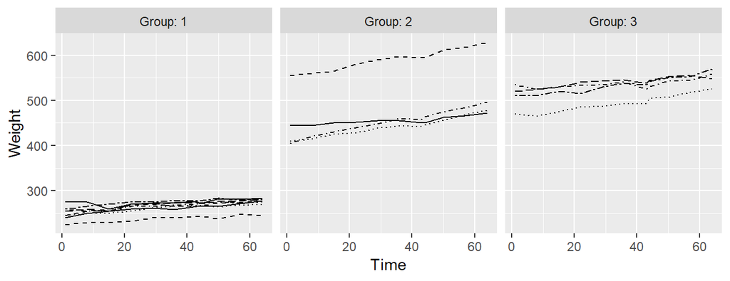

```r
ggplot(RATSL, aes(x = Time, y = Weight, linetype = ID)) +
  geom_line() +
  scale_linetype_manual(values = rep(1:10, times=4)) +
  facet_grid(. ~ Group, labeller = label_both) +
  theme(legend.position = "none") +
  scale_y_continuous(limits = c(min(RATSL$Weight), max(RATSL$Weight)))
```

High start weight shows as high end weight, so data should be standardized.

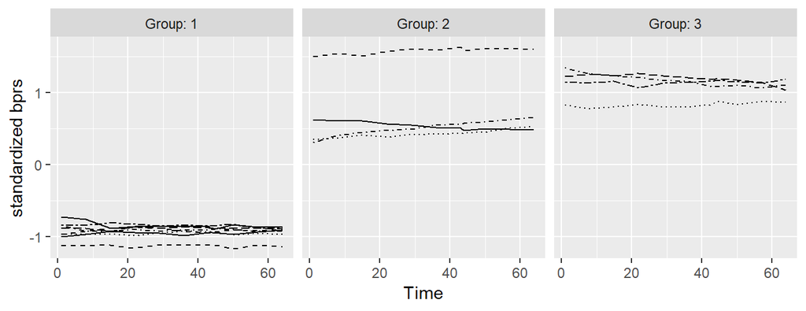

```r
RATSL <- RATSL %>%
  group_by(Time) %>%
  mutate(stdweight = (Weight-mean(Weight))/sd(Weight)) %>%
  ungroup()

ggplot(RATSL, aes(x = Time, y = stdweight, linetype = ID)) +
  geom_line() +
  scale_linetype_manual(values = rep(1:10, times=4)) +
  facet_grid(. ~ Group, labeller = label_both) +
  theme(legend.position = "none") +
  scale_y_continuous(limits = c(min(RATSL$stdweight), max(RATSL$stdweight)), name = "standardized bprs")
```

Now let’s see the response for the diets.

```r
n <- RATSL$Time %>% unique() %>% length()
RATS_trmt <- RATSL %>% group_by(Group, Time) %>% summarize(mean = mean(Weight), se = sd(Weight)/sqrt(n))
glimpse(RATS_trmt)
```

```
## Observations: 33
## Variables: 4
## Groups: Group [3]
## $ Group <fct> 1, 1, 1, 1, 1, 1, 1, 1, 1, 1, 1, 2, 2, 2, 2, 2, 2, 2, 2,...
## $ Time  <int> 1, 8, 15, 22, 29, 36, 43, 44, 50, 57, 64, 1, 8, 15, 22, ...
## $ mean  <dbl> 250.625, 255.000, 254.375, 261.875, 264.625, 265.000, 26...
## $ se    <dbl> 4.589478, 3.947710, 3.460116, 4.100800, 3.333956, 3.5529...
```

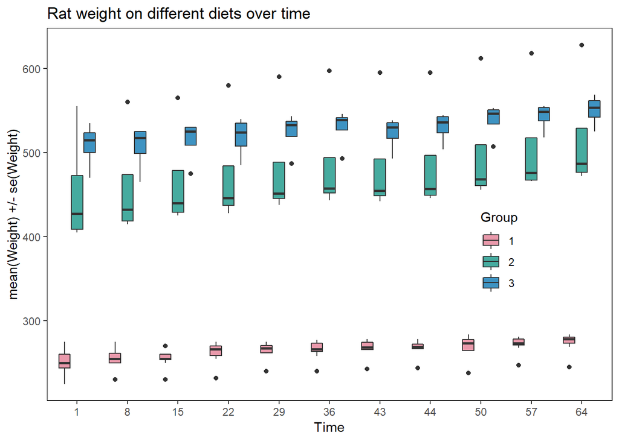

```r
ggplot(RATSL, aes(x= as.factor(Time), y=Weight, fill=Group)) +
  geom_boxplot() +
  theme(legend.position = c(0.8,0.4), panel.grid = element_blank(), panel.background = element_blank(), panel.border = element_rect(fill = FALSE), legend.key = element_rect(fill=FALSE)) +
  scale_y_continuous(name = "mean(Weight) +/- se(Weight)") +
  scale_x_discrete(name = "Time") +
  scale_fill_manual(values=c("#e999ab", "#46ab9f", "#3e93c2")) +
  ggtitle("Rat weight on different diets over time")
```

Rats on diet 1 weigh less than rats on diet 2 and 3, on average.

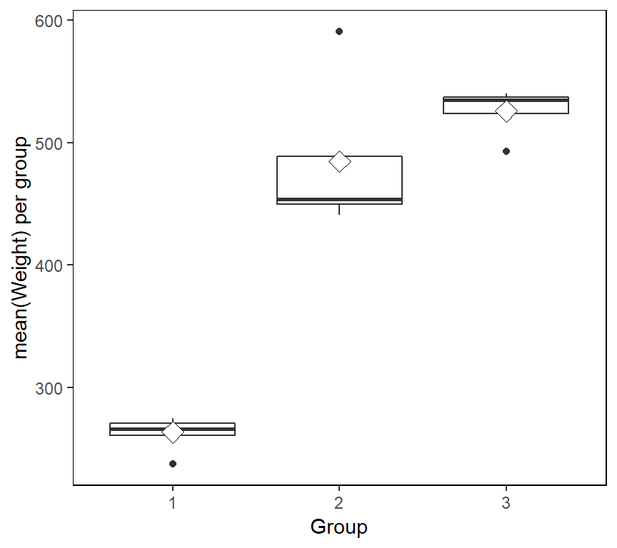

```r
RATSL8 <- RATSL %>%
  group_by(Group, ID) %>%
  summarize(mean = mean(Weight)) %>%
  ungroup()

ggplot(RATSL8, aes(x=Group, y=mean)) +
  geom_boxplot() +
  stat_summary(fun.y = "mean", geom = "point", shape=23, size=4, fill = "white") +
  theme(legend.position = c(0.8,0.8), panel.grid = element_blank(), panel.background = element_blank(), panel.border = element_rect(fill = FALSE)) +
  scale_y_continuous(name = "mean(Weight) per group")
```

There is one outlier in each group, but in group 2 it differs a lot from the mean. Let’s remove it and draw the boxplot again.

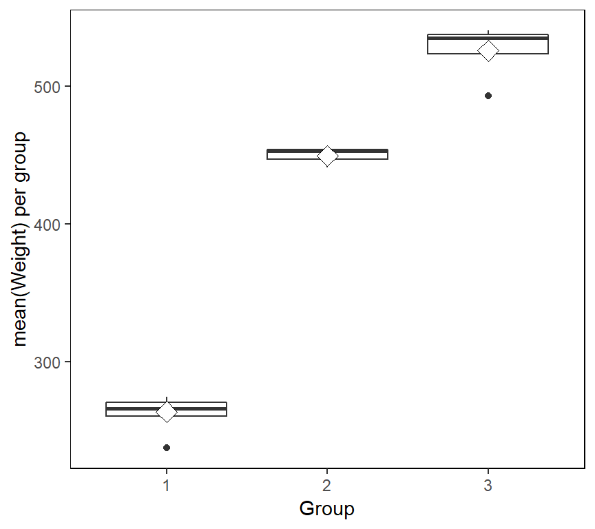

```r
RATSL8S1 <- filter(RATSL8, (Group=="2" & mean<500) | Group!="2")

ggplot(RATSL8S1, aes(x = Group, y = mean)) +
  geom_boxplot() +
  theme(legend.position = c(0.8,0.8), panel.grid = element_blank(), panel.background = element_blank(), panel.border = element_rect(fill = FALSE)) +
  stat_summary(fun.y = "mean", geom = "point", shape=23, size=4, fill = "white") +
  scale_y_continuous(name = "mean(Weight) per group")
```

## BPRSL data

Let’s draw a lineplot for an overview of the data.

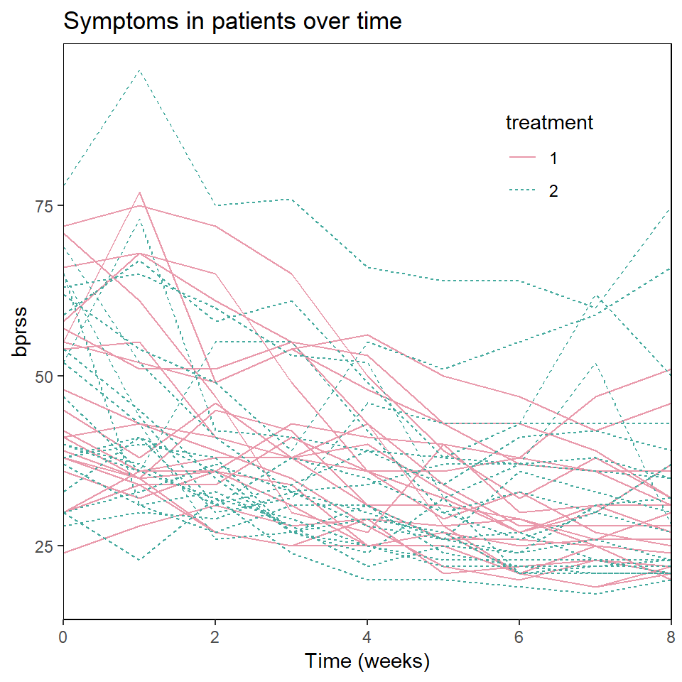

```r
ggplot(BPRSL, aes(x = week, y = bprs, fill=subject, color = treatment)) +
  geom_line(aes(linetype = treatment)) +
  theme(legend.position = c(0.8,0.8), panel.grid = element_blank(), panel.background = element_blank(),
        panel.border = element_rect(fill = FALSE), legend.key = element_rect(fill=FALSE)) +
  scale_x_continuous(name = "Time (weeks)", breaks = seq(0, 8, 2), expand=c(0,0)) +
  scale_y_continuous(name = "bprss") +
  scale_color_manual(values=c("#e999ab", "#46ab9f")) +
  ggtitle("Symptoms in patients over time")
```

Just by eyeballing it seems that with treatment 1 the symptoms have decreased within time, whereas with treatment 2 there is more variation towards the end of the monitoring period.

Let’s fit a Random Intercept Model.

```r
BPRS_ref <- lmer(bprs ~ week + treatment + (1 | subject), data = BPRSL, REML = FALSE)

summary(BPRS_ref)
```

```
## Linear mixed model fit by maximum likelihood  ['lmerMod']
## Formula: bprs ~ week + treatment + (1 | subject)
##    Data: BPRSL
##
##      AIC      BIC   logLik deviance df.resid
##   2748.7   2768.1  -1369.4   2738.7      355
##
## Scaled residuals:
##     Min      1Q  Median      3Q     Max
## -3.0481 -0.6749 -0.1361  0.4813  3.4855
##
## Random effects:
##  Groups   Name        Variance Std.Dev.
##  subject  (Intercept)  47.41    6.885
##  Residual             104.21   10.208
## Number of obs: 360, groups:  subject, 20
##
## Fixed effects:
##             Estimate Std. Error t value
## (Intercept)  46.4539     1.9090  24.334
## week         -2.2704     0.2084 -10.896
## treatment2    0.5722     1.0761   0.532
##
## Correlation of Fixed Effects:
##            (Intr) week
## week       -0.437
## treatment2 -0.282  0.000
```

Now let’s fit a random intercept and random slope model and compare it to the random intercept model.

```r
BPRS_ref1 <- lmer(bprs ~ week + treatment + (week | subject), data = BPRSL, REML = FALSE)

summary(BPRS_ref1)
```

```
## Linear mixed model fit by maximum likelihood  ['lmerMod']
## Formula: bprs ~ week + treatment + (week | subject)
##    Data: BPRSL
##
##      AIC      BIC   logLik deviance df.resid
##   2745.4   2772.6  -1365.7   2731.4      353
##
## Scaled residuals:
##     Min      1Q  Median      3Q     Max
## -2.8919 -0.6194 -0.0691  0.5531  3.7977
##
## Random effects:
##  Groups   Name        Variance Std.Dev. Corr
##  subject  (Intercept) 64.8222  8.0512
##           week         0.9609  0.9803   -0.51
##  Residual             97.4304  9.8707
## Number of obs: 360, groups:  subject, 20
##
## Fixed effects:
##             Estimate Std. Error t value
## (Intercept)  46.4539     2.1052  22.066
## week         -2.2704     0.2977  -7.626
## treatment2    0.5722     1.0405   0.550
##
## Correlation of Fixed Effects:
##            (Intr) week
## week       -0.582
## treatment2 -0.247  0.000
```

```r
anova(BPRS_ref, BPRS_ref1)
```

```
## Data: BPRSL
## Models:
## BPRS_ref: bprs ~ week + treatment + (1 | subject)
## BPRS_ref1: bprs ~ week + treatment + (week | subject)
##           Df    AIC    BIC  logLik deviance  Chisq Chi Df Pr(>Chisq)
## BPRS_ref   5 2748.7 2768.1 -1369.4   2738.7
## BPRS_ref1  7 2745.4 2772.6 -1365.7   2731.4 7.2721      2    0.02636 *
## ---
## Signif. codes:  0 '***' 0.001 '**' 0.01 '*' 0.05 '.' 0.1 ' ' 1
```

Let’s try interaction between week and treatment and compare again.

```r
BPRS_ref2 <- lmer(bprs ~ week * treatment + (week | subject), data = BPRSL, REML = FALSE)

summary(BPRS_ref2)
```

```
## Linear mixed model fit by maximum likelihood  ['lmerMod']
## Formula: bprs ~ week * treatment + (week | subject)
##    Data: BPRSL
##
##      AIC      BIC   logLik deviance df.resid
##   2744.3   2775.4  -1364.1   2728.3      352
##
## Scaled residuals:
##     Min      1Q  Median      3Q     Max
## -3.0512 -0.6271 -0.0768  0.5288  3.9260
##
## Random effects:
##  Groups   Name        Variance Std.Dev. Corr
##  subject  (Intercept) 64.9964  8.0620
##           week         0.9687  0.9842   -0.51
##  Residual             96.4707  9.8220
## Number of obs: 360, groups:  subject, 20
##
## Fixed effects:
##                 Estimate Std. Error t value
## (Intercept)      47.8856     2.2521  21.262
## week             -2.6283     0.3589  -7.323
## treatment2       -2.2911     1.9090  -1.200
## week:treatment2   0.7158     0.4010   1.785
##
## Correlation of Fixed Effects:
##             (Intr) week   trtmn2
## week        -0.650
## treatment2  -0.424  0.469
## wek:trtmnt2  0.356 -0.559 -0.840
```

```r
anova(BPRS_ref2, BPRS_ref1)
```

```
## Data: BPRSL
## Models:
## BPRS_ref1: bprs ~ week + treatment + (week | subject)
## BPRS_ref2: bprs ~ week * treatment + (week | subject)
##           Df    AIC    BIC  logLik deviance  Chisq Chi Df Pr(>Chisq)
## BPRS_ref1  7 2745.4 2772.6 -1365.7   2731.4
## BPRS_ref2  8 2744.3 2775.4 -1364.1   2728.3 3.1712      1    0.07495 .
## ---
## Signif. codes:  0 '***' 0.001 '**' 0.01 '*' 0.05 '.' 0.1 ' ' 1
```

Based on the chi-squared statistics and p-value of the likelihood ratio test, random intercept and random slope model is the best. Let’s plot:

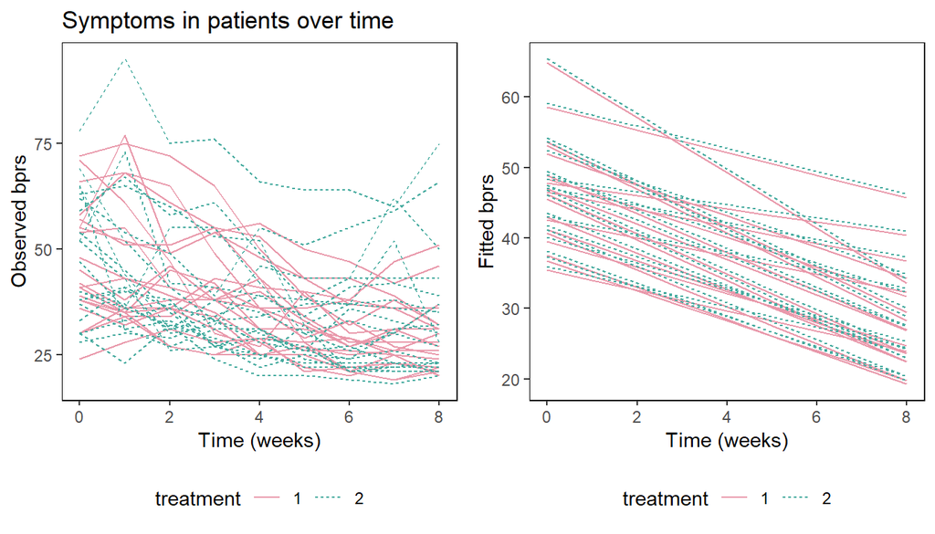

```r
p1 <- ggplot(BPRSL, aes(x = week, y = bprs, fill = subject, color = treatment)) +
  geom_line(aes(linetype = treatment)) +
  scale_x_continuous(name = "Time (weeks)", breaks = seq(0, 8, 2)) +
  scale_y_continuous(name = "Observed bprs") +
    scale_color_manual(values=c("#e999ab", "#46ab9f")) +
    ggtitle("Symptoms in patients over time") +
  theme(panel.grid = element_blank(), panel.background = element_blank(),
        panel.border = element_rect(fill = FALSE), legend.key = element_rect(fill=FALSE), legend.position = "bottom",)
Fitted <- fitted(BPRS_ref1)
BPRSL <- mutate(BPRSL, fitted=Fitted)

p2 <- ggplot(BPRSL, aes(x = week, y = fitted, fill = subject, color = treatment)) +
  geom_line(aes(linetype = treatment)) +
  scale_x_continuous(name = "Time (weeks)", breaks = seq(0, 8, 2)) +
  scale_y_continuous(name = "Fitted bprs") +
  scale_color_manual(values=c("#e999ab", "#46ab9f")) +
    ggtitle(" ") +
  theme(panel.grid = element_blank(), panel.background = element_blank(),
        panel.border = element_rect(fill = FALSE), legend.key = element_rect(fill=FALSE), legend.position = "bottom")


# p1 and p2 side by side
grid.arrange(p1, p2, ncol=2)
```

Based on the fitted model, it looks like the treatments are after all equally effective in reducing the symptoms.